# **Problem Statement**

## **Business Context**

Workplace safety in hazardous environments like construction sites and industrial plants is crucial to prevent accidents and injuries. One of the most important safety measures is ensuring workers wear safety helmets, which protect against head injuries from falling objects and machinery. Non-compliance with helmet regulations increases the risk of serious injuries or fatalities, making effective monitoring essential, especially in large-scale operations where manual oversight is prone to errors and inefficiency.

To overcome these challenges, SafeGuard Corp plans to develop an automated image analysis system capable of detecting whether workers are wearing safety helmets. This system will improve safety enforcement, ensuring compliance and reducing the risk of head injuries. By automating helmet monitoring, SafeGuard aims to enhance efficiency, scalability, and accuracy, ultimately fostering a safer work environment while minimizing human error in safety oversight.

## **Objective**

As a data scientist at SafeGuard Corp, you are tasked with developing an image classification model that classifies images into one of two categories:

- **With Helmet:** Workers wearing safety helmets.
- **Without Helmet:** Workers not wearing safety helmets.

## **Data Description**

The dataset consists of **631 images**, equally divided into two categories:

- **With Helmet:** 311 images showing workers wearing helmets.
- **Without Helmet:** 320 images showing workers not wearing helmets.

**Dataset Characteristics:**

- **Variations in Conditions:** Images include diverse environments such as construction sites, factories, and industrial settings, with variations in lighting, angles, and worker postures to simulate real-world conditions.
- **Worker Activities:** Workers are depicted in different actions such as standing, using tools, or moving, ensuring robust model learning for various scenarios.

# **Installing and Importing the Necessary Libraries**

```python
!pip install tensorflow[and-cuda] numpy==1.25.2 -q
```

```python
import tensorflow as tf
print("Num GPUs Available:", len(tf.config.list_physical_devices('GPU')))
print(tf.__version__)
```

```
Num GPUs Available: 1
2.19.0
```

**Note:**

- After running the above cell, kindly restart the notebook kernel (for Jupyter Notebook) or runtime (for Google Colab) and run all cells sequentially from the next cell.
- On executing the above line of code, you might see a warning regarding package dependencies. This error message can be ignored as the above code ensures that all necessary libraries and their dependencies are maintained to successfully execute the code in this notebook.

```python
import os
import random
import numpy as np                                                                               # Importing numpy for Matrix Operations
import pandas as pd
import seaborn as sns
import matplotlib.image as mpimg                                                                              # Importing pandas to read CSV files
import matplotlib.pyplot as plt                                                                  # Importting matplotlib for Plotting and visualizing images
import math                                                                                      # Importing math module to perform mathematical operations
import cv2


# Tensorflow modules
import keras
import tensorflow as tf
from tensorflow.keras.preprocessing.image import ImageDataGenerator                              # Importing the ImageDataGenerator for data augmentation
from tensorflow.keras.models import Sequential                                                   # Importing the sequential module to define a sequential model
from tensorflow.keras.layers import Dense,Dropout,Flatten,Conv2D,MaxPooling2D,BatchNormalization # Defining all the layers to build our CNN Model
from tensorflow.keras.optimizers import Adam,SGD                                                 # Importing the optimizers which can be used in our model
from sklearn import preprocessing                                                                # Importing the preprocessing module to preprocess the data
from sklearn.model_selection import train_test_split                                             # Importing train_test_split function to split the data into train and test
from sklearn.metrics import confusion_matrix
from tensorflow.keras.models import Model
from keras.applications.vgg16 import VGG16                                               # Importing confusion_matrix to plot the confusion matrix

# Display images using OpenCV
from google.colab.patches import cv2_imshow

#Imports functions for evaluating the performance of machine learning models
from sklearn.metrics import confusion_matrix, f1_score,accuracy_score, recall_score, precision_score, classification_report
from sklearn.metrics import mean_squared_error as mse                                                 # Importing cv2_imshow from google.patches to display images

# Ignore warnings
import warnings
warnings.filterwarnings('ignore')
```

```python
# Set the seed using keras.utils.set_random_seed. This will set:
# 1) `numpy` seed
# 2) backend random seed
# 3) `python` random seed
tf.keras.utils.set_random_seed(812)
```

# **Data Overview**

## Loading the data

```python
labels = pd.read_csv("Labels_proj.csv")
```

```python
labels.shape
```

```
(631, 1)
```

```python
images = np.load("/content/images_proj.npy")
```

```python
print(images.shape)
```

```
(631, 200, 200, 3)
```

# **Exploratory Data Analysis**

### Plot random images from each of the classes and print their corresponding labels.

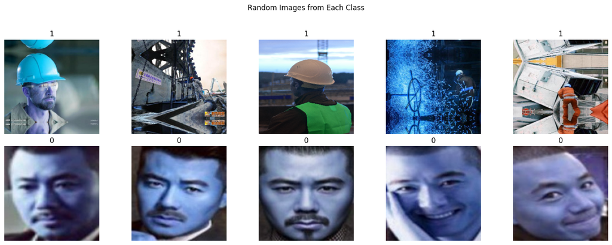

```python
images_per_class = 5
unique_labels = labels['Label'].unique()

# Figure size (adjust depending on number of classes and images per class)
plt.figure(figsize=(images_per_class * 3, len(unique_labels) * 3))

for i, label_val in enumerate(unique_labels):
    # Get indices for the current label
    indices_for_label = labels[labels['Label'] == label_val].index.tolist()

    # Pick random indices (without replacement)
    random_indices = random.sample(indices_for_label, min(images_per_class, len(indices_for_label)))

    for j, idx in enumerate(random_indices):
        plt_idx = i * images_per_class + j + 1
        plt.subplot(len(unique_labels), images_per_class, plt_idx)
        plt.imshow(images[idx])
        plt.title(f"{label_val}")
        plt.axis('off')

plt.suptitle("Random Images from Each Class")
plt.tight_layout(rect=[0, 0.03, 1, 0.95])
plt.show()
```

## Checking for class imbalance

```
Samples per class:
 Label
0    320
1    311
Name: count, dtype: int64
```

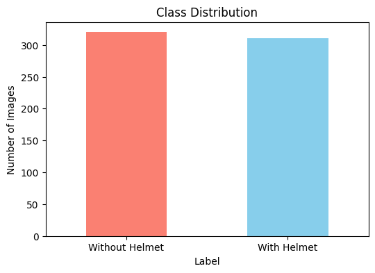

```python
# Count number of samples per class
class_counts = labels['Label'].value_counts()
print("Samples per class:\n", class_counts)

label_names = {0: 'Without Helmet', 1: 'With Helmet'}
class_counts.index = class_counts.index.map(label_names)

# Bar plot
plt.figure(figsize=(6,4))
class_counts.plot(kind='bar', color=['salmon', 'skyblue'])
plt.title("Class Distribution")
plt.ylabel("Number of Images")
plt.xticks(rotation=0)
plt.show()
```

# **Data Preprocessing**

## Converting images to grayscale

```python
gray_images = []

for img in images:
    # Convert to grayscale
    gray = cv2.cvtColor(img, cv2.COLOR_RGB2GRAY)
    gray_images.append(gray)

# Convert list back to NumPy array
gray_images = np.array(gray_images)

print("Original shape:", images.shape)
print("Grayscale shape:", gray_images.shape)
```

```
Original shape: (631, 200, 200, 3)
Grayscale shape: (631, 200, 200)
```

### Before and After

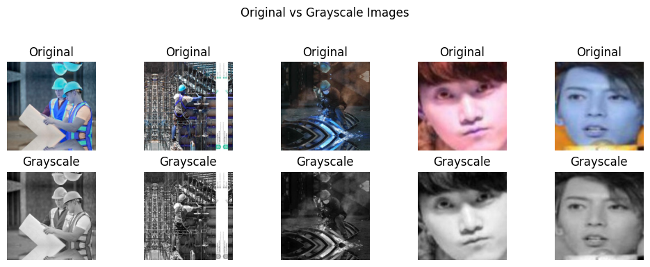

```python
num_images = 5
indices = random.sample(range(len(images)), num_images)

plt.figure(figsize=(10, 4))

for i, idx in enumerate(indices):
    # Original image
    plt.subplot(2, num_images, i + 1)
    plt.imshow(images[idx])
    plt.title("Original")
    plt.axis('off')

    # Grayscale image
    plt.subplot(2, num_images, i + 1 + num_images)
    plt.imshow(gray_images[idx], cmap='gray')
    plt.title("Grayscale")
    plt.axis('off')

plt.suptitle("Original vs Grayscale Images")
plt.tight_layout(rect=[0, 0.03, 1, 0.95])
plt.show()
```

### Splitting the dataset

```python
X_train, X_test, y_train, y_test = train_test_split(
    gray_images,             # images
    labels['Label'].values,  # labels
    test_size=0.2,           # 20% test, 80% train
    random_state=1,         # reproducible split
    stratify=labels['Label'] # preserve class distribution
)

print("Training set shape:", X_train.shape)
print("Test set shape:", X_test.shape)
print("Training labels distribution:\n", np.bincount(y_train))
print("Test labels distribution:\n", np.bincount(y_test))
```

```
Training set shape: (504, 200, 200)
Test set shape: (127, 200, 200)
Training labels distribution:
 [256 248]
Test labels distribution:
 [64 63]
```

### Data Normalization

```python
X_train = X_train.astype('float32')
X_test  = X_test.astype('float32')

X_train /= 255.0
X_test  /= 255.0
```

# **Model Building**

## Model Evaluation Criterion

## Utility Functions

```python
def model_performance_classification(model, predictors, target):
    """
    Compute accuracy, recall, precision, and F1 for a statsmodels or keras binary classifier.
    """

    # Predictions → probabilities
    pred = model.predict(predictors).reshape(-1) > 0.5

    # Convert target safely
    target = np.array(target).reshape(-1)

    acc = accuracy_score(target, pred)
    recall = recall_score(target, pred, average='weighted')
    precision = precision_score(target, pred, average='weighted')
    f1 = f1_score(target, pred, average='weighted')

    df_perf = pd.DataFrame({
        "Accuracy": [acc],
        "Recall": [recall],
        "Precision": [precision],
        "F1 Score": [f1],
    })

    return df_perf
```

```python
def plot_confusion_matrix(model,predictors,target,ml=False):
    """
    Function to plot the confusion matrix

    model: classifier
    predictors: independent variables
    target: dependent variable
    ml: To specify if the model used is an sklearn ML model or not (True means ML model)
    """

    # checking which probabilities are greater than threshold
    pred = model.predict(predictors).reshape(-1)>0.5

    target = target.to_numpy().reshape(-1)

    # Plotting the Confusion Matrix using confusion matrix() function which is also predefined tensorflow module
    confusion_matrix = tf.math.confusion_matrix(target,pred)
    f, ax = plt.subplots(figsize=(10, 8))
    sns.heatmap(
        confusion_matrix,
        annot=True,
        linewidths=.4,
        fmt="d",
        square=True,
        ax=ax
    )
    plt.show()
```

[output not shown]

```python
X_train_cnn = X_train[..., np.newaxis]  # shape: (num_samples, height, width, 1)
X_test_cnn  = X_test[..., np.newaxis]

print("X_train shape for CNN:", X_train_cnn.shape)
print("X_test shape for CNN:", X_test_cnn.shape)
```

```
X_train shape for CNN: (504, 200, 200, 1)
X_test shape for CNN: (127, 200, 200, 1)
```

## Model 1: Simple Convolutional Neural Network (CNN)

```python
input_shape = X_train_cnn.shape[1:]  # (height, width, 1)

model = Sequential([
    Conv2D(32, (3,3), activation='relu', input_shape=input_shape),
    MaxPooling2D((2,2)),
    Flatten(),
    Dense(16, activation='relu'),
    Dense(1, activation='sigmoid')  # binary classification
])

model.summary()
```

```
Model: "sequential_20"
```

```
┏━━━━━━━━━━━━━━━━━━━━━━━━━━━━━━━━━┳━━━━━━━━━━━━━━━━━━━━━━━━┳━━━━━━━━━━━━━━━┓
┃ Layer (type)                    ┃ Output Shape           ┃       Param # ┃
┡━━━━━━━━━━━━━━━━━━━━━━━━━━━━━━━━━╇━━━━━━━━━━━━━━━━━━━━━━━━╇━━━━━━━━━━━━━━━┩
│ conv2d_25 (Conv2D)              │ (None, 198, 198, 32)   │           320 │
├─────────────────────────────────┼────────────────────────┼───────────────┤
│ max_pooling2d_25 (MaxPooling2D) │ (None, 99, 99, 32)     │             0 │
├─────────────────────────────────┼────────────────────────┼───────────────┤
│ flatten_20 (Flatten)            │ (None, 313632)         │             0 │
├─────────────────────────────────┼────────────────────────┼───────────────┤
│ dense_40 (Dense)                │ (None, 16)             │     5,018,128 │
├─────────────────────────────────┼────────────────────────┼───────────────┤
│ dense_41 (Dense)                │ (None, 1)              │            17 │
└─────────────────────────────────┴────────────────────────┴───────────────┘
```

```
 Total params: 5,018,465 (19.14 MB)
```

```
 Trainable params: 5,018,465 (19.14 MB)
```

```
 Non-trainable params: 0 (0.00 B)
```

```python
model.compile(
    optimizer='adam',
    loss='binary_crossentropy',  # for binary classification
    metrics=['accuracy']
)
```

```python
history = model.fit(
    X_train, y_train,
    epochs=5,             # adjust as needed
    batch_size=32,
    verbose=1
)
```

```
16/16 ━━━━━━━━━━━━━━━━━━━━ 3s 95ms/step - accuracy: 0.5294 - loss: 2.2283
16/16 ━━━━━━━━━━━━━━━━━━━━ 0s 21ms/step - accuracy: 0.5447 - loss: 0.6931
16/16 ━━━━━━━━━━━━━━━━━━━━ 0s 22ms/step - accuracy: 0.5226 - loss: 0.6931
16/16 ━━━━━━━━━━━━━━━━━━━━ 0s 20ms/step - accuracy: 0.5127 - loss: 0.6931
16/16 ━━━━━━━━━━━━━━━━━━━━ 0s 19ms/step - accuracy: 0.5289 - loss: 0.6930
```

### Vizualizing the predictions

```python
# Predict probabilities
y_pred_prob = model.predict(X_test_cnn)

# Convert probabilities to 0/1
y_pred = (y_pred_prob > 0.5).astype(int).reshape(-1)

# Compute metrics
acc = accuracy_score(y_test, y_pred)
recall = recall_score(y_test, y_pred, average='weighted')
precision = precision_score(y_test, y_pred, average='weighted')
f1 = f1_score(y_test, y_pred, average='weighted')

df_perf = pd.DataFrame({
    "Accuracy": [acc],
    "Recall": [recall],
    "Precision": [precision],
    "F1 Score": [f1]
})

print(df_perf)
```

```
4/4 ━━━━━━━━━━━━━━━━━━━━ 0s 80ms/step
   Accuracy    Recall  Precision  F1 Score
0  0.503937  0.503937   0.253953  0.337717
```

```
1/1 ━━━━━━━━━━━━━━━━━━━━ 0s 290ms/step
1/1 ━━━━━━━━━━━━━━━━━━━━ 0s 29ms/step
1/1 ━━━━━━━━━━━━━━━━━━━━ 0s 29ms/step
1/1 ━━━━━━━━━━━━━━━━━━━━ 0s 28ms/step
1/1 ━━━━━━━━━━━━━━━━━━━━ 0s 30ms/step
1/1 ━━━━━━━━━━━━━━━━━━━━ 0s 29ms/step
1/1 ━━━━━━━━━━━━━━━━━━━━ 0s 28ms/step
1/1 ━━━━━━━━━━━━━━━━━━━━ 0s 29ms/step
```

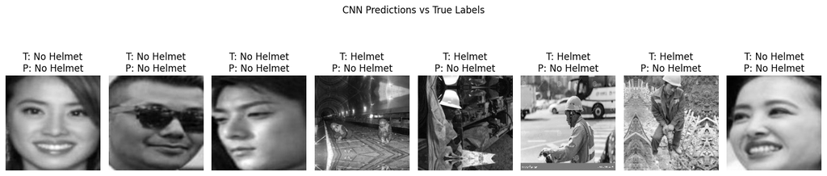

```python
num_images = 8
indices = np.random.choice(len(X_test_cnn), num_images, replace=False)

plt.figure(figsize=(15, 4))

for i, idx in enumerate(indices):
    img = X_test_cnn[idx].squeeze()  # remove channel dimension
    true_label = y_test[idx]
    pred_label = (model.predict(X_test_cnn[idx:idx+1]) > 0.5).astype(int)[0][0]

    plt.subplot(1, num_images, i+1)
    plt.imshow(img, cmap='gray')
    plt.title(f"T: {'Helmet' if true_label==1 else 'No Helmet'}\nP: {'Helmet' if pred_label==1 else 'No Helmet'}")
    plt.axis('off')

plt.suptitle("CNN Predictions vs True Labels")
plt.tight_layout(rect=[0, 0.03, 1, 0.95])
plt.show()
```

### Comments

As, the current model is quite small (only a single CNN layer and a single connected layer), hence the accuracy is also quite low. But, we can improve on it later!

## Model 2: (VGG-16 (Base)):

```python
X_train_vgg = np.repeat(X_train[..., np.newaxis], 3, axis=-1)  # (num_samples, H, W, 3)
X_test_vgg  = np.repeat(X_test[..., np.newaxis], 3, axis=-1)

print("X_train shape for VGG-16:", X_train_vgg.shape)
print("X_test shape for VGG-16:", X_test_vgg.shape)
```

```
X_train shape for VGG-16: (504, 200, 200, 3)
X_test shape for VGG-16: (127, 200, 200, 3)
```

```python
vgg_base = VGG16(weights='imagenet', include_top=False, input_shape=X_train_vgg.shape[1:])

# Freeze base layers to keep pre-trained features
for layer in vgg_base.layers:
    layer.trainable = False
```

```
Downloading data from https://storage.googleapis.com/tensorflow/keras-applications/vgg16/vgg16_weights_tf_dim_ordering_tf_kernels_notop.h5
58889256/58889256 ━━━━━━━━━━━━━━━━━━━━ 0s 0us/step
```

```python
model_vgg = Sequential([
    vgg_base,
    Flatten(),
    Dense(256, activation='relu'),
    Dropout(0.5),
    Dense(1, activation='sigmoid')  # binary classification
])

model_vgg.summary()
```

```
Model: "sequential_21"
```

```
┏━━━━━━━━━━━━━━━━━━━━━━━━━━━━━━━━━┳━━━━━━━━━━━━━━━━━━━━━━━━┳━━━━━━━━━━━━━━━┓
┃ Layer (type)                    ┃ Output Shape           ┃       Param # ┃
┡━━━━━━━━━━━━━━━━━━━━━━━━━━━━━━━━━╇━━━━━━━━━━━━━━━━━━━━━━━━╇━━━━━━━━━━━━━━━┩
│ vgg16 (Functional)              │ (None, 6, 6, 512)      │    14,714,688 │
├─────────────────────────────────┼────────────────────────┼───────────────┤
│ flatten_21 (Flatten)            │ (None, 18432)          │             0 │
├─────────────────────────────────┼────────────────────────┼───────────────┤
│ dense_42 (Dense)                │ (None, 256)            │     4,718,848 │
├─────────────────────────────────┼────────────────────────┼───────────────┤
│ dropout_5 (Dropout)             │ (None, 256)            │             0 │
├─────────────────────────────────┼────────────────────────┼───────────────┤
│ dense_43 (Dense)                │ (None, 1)              │           257 │
└─────────────────────────────────┴────────────────────────┴───────────────┘
```

```
 Total params: 19,433,793 (74.13 MB)
```

```
 Trainable params: 4,719,105 (18.00 MB)
```

```
 Non-trainable params: 14,714,688 (56.13 MB)
```

```python
model_vgg.compile(
    optimizer=Adam(learning_rate=1e-4),
    loss='binary_crossentropy',
    metrics=['accuracy']
)
```

```python
history_vgg = model_vgg.fit(
    X_train_vgg, y_train,
    epochs=10,
    batch_size=32,
    validation_split=0.2,
    verbose=1
)
```

```
13/13 ━━━━━━━━━━━━━━━━━━━━ 30s 1s/step - accuracy: 0.8323 - loss: 0.3863 - val_accuracy: 1.0000 - val_loss: 0.0144
13/13 ━━━━━━━━━━━━━━━━━━━━ 2s 189ms/step - accuracy: 1.0000 - loss: 0.0167 - val_accuracy: 1.0000 - val_loss: 0.0029
13/13 ━━━━━━━━━━━━━━━━━━━━ 2s 189ms/step - accuracy: 1.0000 - loss: 0.0047 - val_accuracy: 1.0000 - val_loss: 0.0021
13/13 ━━━━━━━━━━━━━━━━━━━━ 3s 197ms/step - accuracy: 1.0000 - loss: 0.0021 - val_accuracy: 1.0000 - val_loss: 0.0037
13/13 ━━━━━━━━━━━━━━━━━━━━ 3s 196ms/step - accuracy: 1.0000 - loss: 0.0019 - val_accuracy: 1.0000 - val_loss: 0.0017
13/13 ━━━━━━━━━━━━━━━━━━━━ 2s 191ms/step - accuracy: 1.0000 - loss: 0.0011 - val_accuracy: 1.0000 - val_loss: 0.0017
13/13 ━━━━━━━━━━━━━━━━━━━━ 2s 193ms/step - accuracy: 1.0000 - loss: 9.3299e-04 - val_accuracy: 1.0000 - val_loss: 0.0022
13/13 ━━━━━━━━━━━━━━━━━━━━ 3s 198ms/step - accuracy: 1.0000 - loss: 9.1608e-04 - val_accuracy: 1.0000 - val_loss: 0.0024
13/13 ━━━━━━━━━━━━━━━━━━━━ 3s 220ms/step - accuracy: 1.0000 - loss: 6.3275e-04 - val_accuracy: 1.0000 - val_loss: 0.0018
13/13 ━━━━━━━━━━━━━━━━━━━━ 3s 206ms/step - accuracy: 1.0000 - loss: 3.7123e-04 - val_accuracy: 1.0000 - val_loss: 0.0021
```

```python
y_pred_prob = model_vgg.predict(X_test_vgg)
y_pred = (y_pred_prob > 0.5).astype(int).reshape(-1)

acc = accuracy_score(y_test, y_pred)
recall = recall_score(y_test, y_pred, average='weighted')
precision = precision_score(y_test, y_pred, average='weighted')
f1 = f1_score(y_test, y_pred, average='weighted')

df_perf_vgg = pd.DataFrame({
    "Accuracy": [acc],
    "Recall": [recall],
    "Precision": [precision],
    "F1 Score": [f1]
})

print(df_perf_vgg)
```

```
4/4 ━━━━━━━━━━━━━━━━━━━━ 16s 4s/step
   Accuracy  Recall  Precision  F1 Score
0       1.0     1.0        1.0       1.0
```

### Visualizing the prediction:

```
1/1 ━━━━━━━━━━━━━━━━━━━━ 0s 238ms/step
1/1 ━━━━━━━━━━━━━━━━━━━━ 0s 67ms/step
1/1 ━━━━━━━━━━━━━━━━━━━━ 0s 99ms/step
1/1 ━━━━━━━━━━━━━━━━━━━━ 0s 115ms/step
1/1 ━━━━━━━━━━━━━━━━━━━━ 0s 110ms/step
1/1 ━━━━━━━━━━━━━━━━━━━━ 0s 83ms/step
1/1 ━━━━━━━━━━━━━━━━━━━━ 0s 62ms/step
1/1 ━━━━━━━━━━━━━━━━━━━━ 0s 100ms/step
```

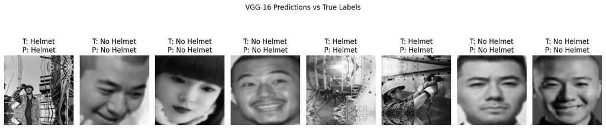

```python
num_images = 8
indices = np.random.choice(len(X_test_vgg), num_images, replace=False)

plt.figure(figsize=(15, 4))

for i, idx in enumerate(indices):
    img = X_test_vgg[idx]  # already scaled [0,1]

    pred_label = (model_vgg.predict(img[np.newaxis, ...]) > 0.5).astype(int)[0][0]
    true_label = y_test[idx]

    plt.subplot(1, num_images, i+1)
    plt.imshow(img)  # keep float in [0,1]
    plt.title(f"T: {'Helmet' if true_label==1 else 'No Helmet'}\nP: {'Helmet' if pred_label==1 else 'No Helmet'}")
    plt.axis('off')

plt.suptitle("VGG-16 Predictions vs True Labels")
plt.tight_layout(rect=[0, 0.03, 1, 0.95])
plt.show()
```

### Comments

The dataset was quite simple and VGG-16 proved to be an overkill for it!

## Model 3: (VGG-16 (Base + FFNN))

```python
model_vgg_ffnn = Sequential([
    vgg_base,
    Flatten(),
    Dense(512, activation='relu'),
    Dropout(0.5),
    Dense(256, activation='relu'),
    Dropout(0.3),
    Dense(1, activation='sigmoid')  # binary classification
])

model_vgg_ffnn.summary()
```

```
Model: "sequential_22"
```

```
┏━━━━━━━━━━━━━━━━━━━━━━━━━━━━━━━━━┳━━━━━━━━━━━━━━━━━━━━━━━━┳━━━━━━━━━━━━━━━┓
┃ Layer (type)                    ┃ Output Shape           ┃       Param # ┃
┡━━━━━━━━━━━━━━━━━━━━━━━━━━━━━━━━━╇━━━━━━━━━━━━━━━━━━━━━━━━╇━━━━━━━━━━━━━━━┩
│ vgg16 (Functional)              │ (None, 6, 6, 512)      │    14,714,688 │
├─────────────────────────────────┼────────────────────────┼───────────────┤
│ flatten_22 (Flatten)            │ (None, 18432)          │             0 │
├─────────────────────────────────┼────────────────────────┼───────────────┤
│ dense_44 (Dense)                │ (None, 512)            │     9,437,696 │
├─────────────────────────────────┼────────────────────────┼───────────────┤
│ dropout_6 (Dropout)             │ (None, 512)            │             0 │
├─────────────────────────────────┼────────────────────────┼───────────────┤
│ dense_45 (Dense)                │ (None, 256)            │       131,328 │
├─────────────────────────────────┼────────────────────────┼───────────────┤
│ dropout_7 (Dropout)             │ (None, 256)            │             0 │
├─────────────────────────────────┼────────────────────────┼───────────────┤
│ dense_46 (Dense)                │ (None, 1)              │           257 │
└─────────────────────────────────┴────────────────────────┴───────────────┘
```

```
 Total params: 24,283,969 (92.64 MB)
```

```
 Trainable params: 9,569,281 (36.50 MB)
```

```
 Non-trainable params: 14,714,688 (56.13 MB)
```

```python
model_vgg_ffnn.compile(
    optimizer=Adam(learning_rate=1e-4),
    loss='binary_crossentropy',
    metrics=['accuracy']
)
```

```python
history_vgg_ffnn = model_vgg_ffnn.fit(
    X_train_vgg, y_train,
    epochs=10,           # adjust as needed
    batch_size=32,
    validation_split=0.2,
    verbose=1
)
```

```
13/13 ━━━━━━━━━━━━━━━━━━━━ 12s 501ms/step - accuracy: 0.7736 - loss: 0.4394 - val_accuracy: 1.0000 - val_loss: 0.0183
13/13 ━━━━━━━━━━━━━━━━━━━━ 2s 190ms/step - accuracy: 0.9946 - loss: 0.0331 - val_accuracy: 1.0000 - val_loss: 0.0037
13/13 ━━━━━━━━━━━━━━━━━━━━ 2s 189ms/step - accuracy: 0.9982 - loss: 0.0079 - val_accuracy: 1.0000 - val_loss: 0.0017
13/13 ━━━━━━━━━━━━━━━━━━━━ 2s 190ms/step - accuracy: 1.0000 - loss: 0.0052 - val_accuracy: 1.0000 - val_loss: 6.7757e-04
13/13 ━━━━━━━━━━━━━━━━━━━━ 2s 190ms/step - accuracy: 1.0000 - loss: 0.0023 - val_accuracy: 1.0000 - val_loss: 7.3959e-04
13/13 ━━━━━━━━━━━━━━━━━━━━ 3s 194ms/step - accuracy: 1.0000 - loss: 0.0019 - val_accuracy: 1.0000 - val_loss: 9.9982e-04
13/13 ━━━━━━━━━━━━━━━━━━━━ 2s 192ms/step - accuracy: 1.0000 - loss: 0.0010 - val_accuracy: 1.0000 - val_loss: 8.3830e-04
13/13 ━━━━━━━━━━━━━━━━━━━━ 2s 192ms/step - accuracy: 1.0000 - loss: 0.0011 - val_accuracy: 1.0000 - val_loss: 7.1865e-04
13/13 ━━━━━━━━━━━━━━━━━━━━ 2s 193ms/step - accuracy: 1.0000 - loss: 4.4489e-04 - val_accuracy: 1.0000 - val_loss: 4.6588e-04
13/13 ━━━━━━━━━━━━━━━━━━━━ 2s 193ms/step - accuracy: 1.0000 - loss: 4.9814e-04 - val_accuracy: 1.0000 - val_loss: 3.6925e-04
```

```python
y_pred_prob = model_vgg_ffnn.predict(X_test_vgg)
y_pred = (y_pred_prob > 0.5).astype(int).reshape(-1)

acc = accuracy_score(y_test, y_pred)
recall = recall_score(y_test, y_pred, average='weighted')
precision = precision_score(y_test, y_pred, average='weighted')
f1 = f1_score(y_test, y_pred, average='weighted')

df_perf_vgg_ffnn = pd.DataFrame({
    "Accuracy": [acc],
    "Recall": [recall],
    "Precision": [precision],
    "F1 Score": [f1]
})

print(df_perf_vgg_ffnn)
```

```
4/4 ━━━━━━━━━━━━━━━━━━━━ 2s 378ms/step
   Accuracy  Recall  Precision  F1 Score
0       1.0     1.0        1.0       1.0
```

#### Visualizing the predictions

```
1/1 ━━━━━━━━━━━━━━━━━━━━ 2s 2s/step
1/1 ━━━━━━━━━━━━━━━━━━━━ 0s 65ms/step
1/1 ━━━━━━━━━━━━━━━━━━━━ 0s 71ms/step
1/1 ━━━━━━━━━━━━━━━━━━━━ 0s 63ms/step
1/1 ━━━━━━━━━━━━━━━━━━━━ 0s 62ms/step
1/1 ━━━━━━━━━━━━━━━━━━━━ 0s 93ms/step
1/1 ━━━━━━━━━━━━━━━━━━━━ 0s 63ms/step
1/1 ━━━━━━━━━━━━━━━━━━━━ 0s 56ms/step
```

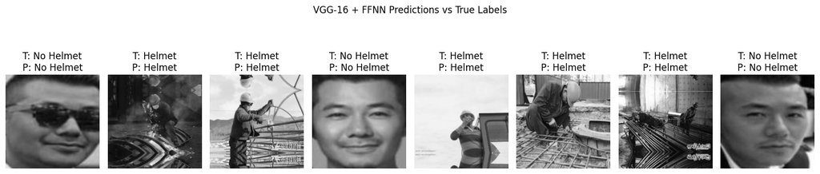

```python
num_images = 8
indices = np.random.choice(len(X_test_vgg), num_images, replace=False)

plt.figure(figsize=(15, 4))

for i, idx in enumerate(indices):
    img = X_test_vgg[idx]  # 3-channel image
    true_label = y_test[idx]

    # Predict label
    pred_label = (model_vgg_ffnn.predict(img[np.newaxis, ...]) > 0.5).astype(int)[0][0]

    # Show image
    plt.subplot(1, num_images, i+1)
    plt.imshow(img)  # float images in [0,1]

    # Color title red if wrong, black if correct
    title_color = 'red' if pred_label != true_label else 'black'
    plt.title(f"T: {'Helmet' if true_label==1 else 'No Helmet'}\nP: {'Helmet' if pred_label==1 else 'No Helmet'}",
              color=title_color)
    plt.axis('off')

plt.suptitle("VGG-16 + FFNN Predictions vs True Labels")
plt.tight_layout(rect=[0, 0.03, 1, 0.95])
plt.show()
```

**Comments**: Once again, an advanced technique of using VGG-16 with FFNN proved to be an overkill for the dataset, as it achieved 100% accuracy on both train and test sets

## Model 4: (VGG-16 (Base + FFNN + Data Augmentation)

- In most of the real-world case studies, it is challenging to acquire a large number of images and then train CNNs.
- To overcome this problem, one approach we might consider is **Data Augmentation**.
- CNNs have the property of **translational invariance**, which means they can recognise an object even if its appearance shifts translationally in some way. - Taking this attribute into account, we can augment the images using the techniques listed below
  - Horizontal Flip (should be set to True/False)
  - Vertical Flip (should be set to True/False)
  - Height Shift (should be between 0 and 1)
  - Width Shift (should be between 0 and 1)
  - Rotation (should be between 0 and 180)
  - Shear (should be between 0 and 1)
  - Zoom (should be between 0 and 1) etc.

Remember, **data augmentation should not be used in the validation/test data set**.

```python
train_datagen = ImageDataGenerator(
    rotation_range=20,       # rotate images up to 20 degrees
    width_shift_range=0.1,   # shift horizontally up to 10% of width
    height_shift_range=0.1,  # shift vertically up to 10% of height
    shear_range=0.1,         # shear transformation
    zoom_range=0.1,          # zoom in/out
    horizontal_flip=True,    # randomly flip horizontally
    vertical_flip=False,     # rarely vertical flip for real-world images
    fill_mode='nearest'      # fill missing pixels after transformations
)

val_datagen = ImageDataGenerator()
```

```python
# Convert grayscale to 3-channel for VGG-16
X_train_aug = np.repeat(X_train[..., np.newaxis], 3, axis=-1)
X_test_aug  = np.repeat(X_test[..., np.newaxis], 3, axis=-1)

# Create generators
train_generator = train_datagen.flow(X_train_aug, y_train, batch_size=32)
val_generator   = val_datagen.flow(X_test_aug, y_test, batch_size=32)
```

```python
model_vgg_ffnn_aug = Sequential([
    vgg_base,
    Flatten(),
    Dense(512, activation='relu'),
    Dropout(0.5),
    Dense(256, activation='relu'),
    Dropout(0.3),
    Dense(1, activation='sigmoid')
])

model_vgg_ffnn_aug.compile(
    optimizer=Adam(learning_rate=1e-4),
    loss='binary_crossentropy',
    metrics=['accuracy']
)
```

```python
history_aug = model_vgg_ffnn_aug.fit(
    train_generator,
    epochs=10,
    validation_data=val_generator,
    verbose=1
)
```

```
16/16 ━━━━━━━━━━━━━━━━━━━━ 17s 1s/step - accuracy: 0.7968 - loss: 0.3929 - val_accuracy: 1.0000 - val_loss: 0.0183
16/16 ━━━━━━━━━━━━━━━━━━━━ 6s 390ms/step - accuracy: 0.9982 - loss: 0.0274 - val_accuracy: 1.0000 - val_loss: 0.0067
16/16 ━━━━━━━━━━━━━━━━━━━━ 5s 334ms/step - accuracy: 1.0000 - loss: 0.0069 - val_accuracy: 1.0000 - val_loss: 0.0034
16/16 ━━━━━━━━━━━━━━━━━━━━ 6s 389ms/step - accuracy: 0.9998 - loss: 0.0034 - val_accuracy: 1.0000 - val_loss: 0.0027
16/16 ━━━━━━━━━━━━━━━━━━━━ 5s 338ms/step - accuracy: 0.9984 - loss: 0.0063 - val_accuracy: 1.0000 - val_loss: 0.0020
16/16 ━━━━━━━━━━━━━━━━━━━━ 6s 385ms/step - accuracy: 1.0000 - loss: 0.0018 - val_accuracy: 1.0000 - val_loss: 0.0027
16/16 ━━━━━━━━━━━━━━━━━━━━ 5s 333ms/step - accuracy: 1.0000 - loss: 0.0018 - val_accuracy: 1.0000 - val_loss: 0.0039
16/16 ━━━━━━━━━━━━━━━━━━━━ 6s 382ms/step - accuracy: 0.9970 - loss: 0.0075 - val_accuracy: 1.0000 - val_loss: 8.6308e-04
16/16 ━━━━━━━━━━━━━━━━━━━━ 6s 344ms/step - accuracy: 1.0000 - loss: 0.0016 - val_accuracy: 1.0000 - val_loss: 0.0017
16/16 ━━━━━━━━━━━━━━━━━━━━ 8s 490ms/step - accuracy: 1.0000 - loss: 0.0022 - val_accuracy: 1.0000 - val_loss: 0.0033
```

```python
y_pred_prob = model_vgg_ffnn_aug.predict(X_test_aug).reshape(-1)

y_pred = (y_pred_prob > 0.5).astype(int)

acc = accuracy_score(y_test, y_pred)
recall = recall_score(y_test, y_pred, average='weighted')
precision = precision_score(y_test, y_pred, average='weighted')
f1 = f1_score(y_test, y_pred, average='weighted')

df_perf_vgg_ffnn_aug = pd.DataFrame({
    "Accuracy": [acc],
    "Recall": [recall],
    "Precision": [precision],
    "F1 Score": [f1]
})

print(df_perf_vgg_ffnn_aug)
```

```
4/4 ━━━━━━━━━━━━━━━━━━━━ 1s 161ms/step
   Accuracy  Recall  Precision  F1 Score
0       1.0     1.0        1.0       1.0
```

#### Visualizing the predictions

```
1/1 ━━━━━━━━━━━━━━━━━━━━ 0s 51ms/step
1/1 ━━━━━━━━━━━━━━━━━━━━ 0s 49ms/step
1/1 ━━━━━━━━━━━━━━━━━━━━ 0s 54ms/step
1/1 ━━━━━━━━━━━━━━━━━━━━ 0s 48ms/step
1/1 ━━━━━━━━━━━━━━━━━━━━ 0s 54ms/step
1/1 ━━━━━━━━━━━━━━━━━━━━ 0s 52ms/step
1/1 ━━━━━━━━━━━━━━━━━━━━ 0s 49ms/step
1/1 ━━━━━━━━━━━━━━━━━━━━ 0s 48ms/step
```

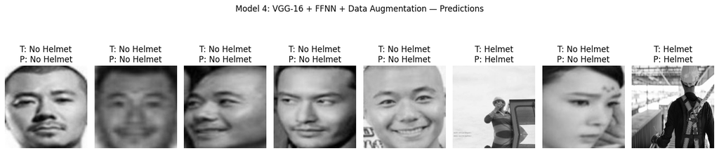

```python
num_images = 8
indices = np.random.choice(len(X_test_aug), num_images, replace=False)

plt.figure(figsize=(15, 4))

for i, idx in enumerate(indices):
    img = X_test_aug[idx]      # 3-channel image (after grayscale → 3-channel)
    true_label = y_test[idx]

    # Predict
    pred_prob = model_vgg_ffnn_aug.predict(img[np.newaxis, ...])[0][0]
    pred_label = int(pred_prob > 0.5)

    # Plot
    plt.subplot(1, num_images, i+1)
    plt.imshow(img)

    # Title color = red if wrong
    color = 'red' if pred_label != true_label else 'black'
    plt.title(
        f"T: {'Helmet' if true_label==1 else 'No Helmet'}\n"
        f"P: {'Helmet' if pred_label==1 else 'No Helmet'}",
        color=color
    )
    plt.axis('off')

plt.suptitle("Model 4: VGG-16 + FFNN + Data Augmentation — Predictions")
plt.tight_layout(rect=[0, 0.03, 1, 0.95])
plt.show()
```

**Comments** Once again it proved out to be an overkill, the dataset is quite simple and the images with and without helmet are quite different from each other. Hence, very easy for a complex model like this to tell the difference